# R Notebook

#boxplot of age # Create a boxplot to visualize the distribution of ages in our dataset, it includes the median, quartiles, and potential outliers of the age variable.

```r
 boxplot.stats(brain_stroke$age)$out
```

```
numeric(0)
```

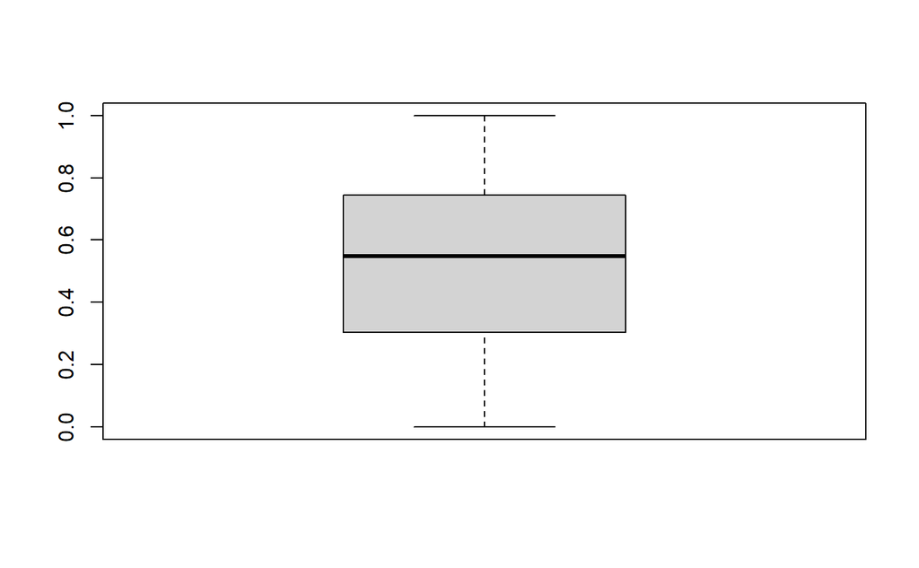

```r
 boxplot(brain_stroke$age)
```

#boxplot of avg_glucose_level # Create a boxplot to visualize the distribution of avg_glucose_level in our dataset, it includes the median, quartiles, and potential outliers of the avg_glucose_level variable.

```r
 boxplot.stats(brain_stroke$avg_glucose_level)$out
```

```
numeric(0)
```

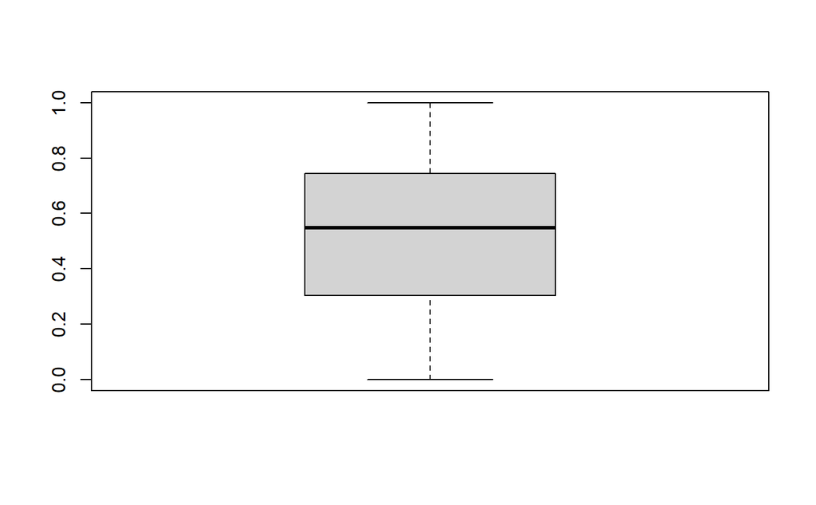

```r
 boxplot(brain_stroke$avg_glucose_level)
```

#boxplot of bmi # Create a boxplot to visualize the distribution of bmi in our dataset, it includes the median, quartiles, and potential outliers of the bmi variable.

```r
 boxplot.stats(brain_stroke$bmi)$out
```

```
 [1] 1.0000000 0.9598854 0.9169054 0.9799427 0.9541547 0.9312321 0.9340974 0.9684814
 [9] 0.9197708 0.9856734 0.9226361 0.9598854 0.9885387 1.0000000 0.9885387 0.9942693
[17] 1.0000000 0.9312321 0.9971347 0.9169054 0.9742120 0.9398281 0.9828080 0.9828080
[25] 0.9570201 0.9541547 0.9713467 0.9226361 0.9197708 0.9169054 0.9627507 0.9971347
[33] 0.9598854 0.9283668 0.9426934 0.9484241 0.9770774 0.9684814 0.9627507 0.9255014
[41] 0.9169054 0.9627507 0.9426934
```

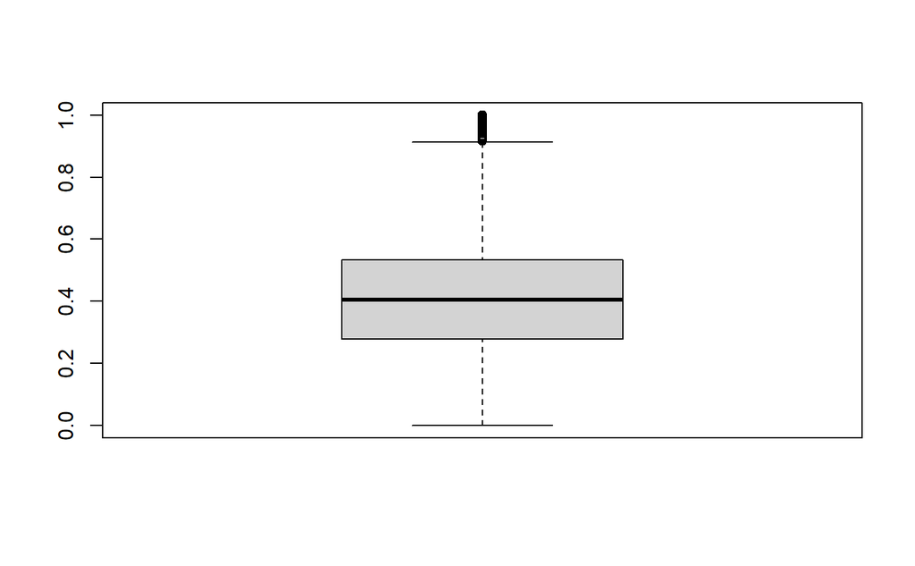

```r
 boxplot(brain_stroke$bmi)
```

#histogram

# Shows Distribution of ages

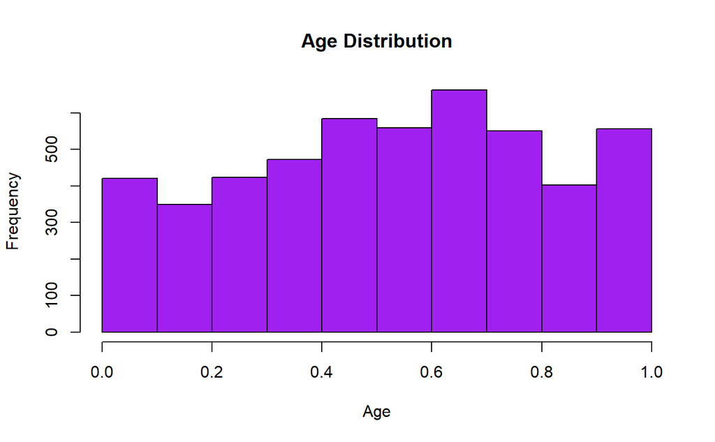

#Scatter plot

# Shows the relationship between two attributes: “average glucose level” (on the x-axis) and “BMI” (Body Mass Index, on the y-axis)

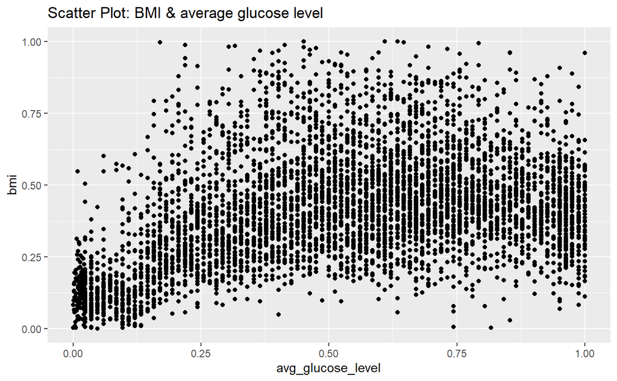

```r
ggplot(brain_stroke, aes(x = avg_glucose_level, y = bmi)) +
  geom_point() +
  labs(title = "Scatter Plot: BMI & average glucose level")

cor(brain_stroke$avg_glucose_level, brain_stroke$bmi)
```

```
[1] 0.3737031
```

#pie charts

# Shows Distribution of Residence Types

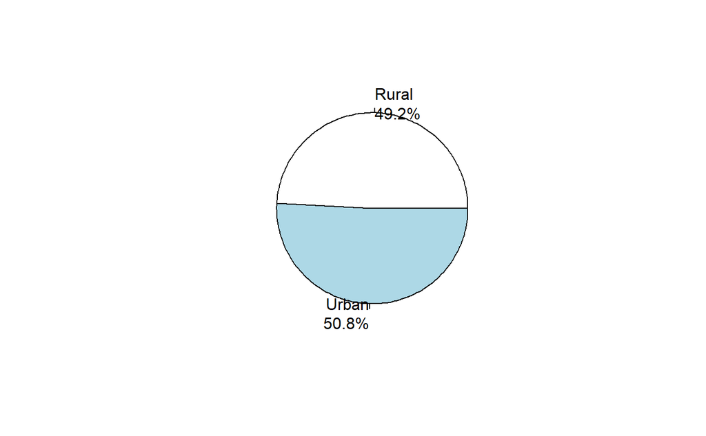

#We notice from this pie chart that the majority of people in this dataset live in urban residence

#Bar Plots

# 1 - Shows the disturbution of work type

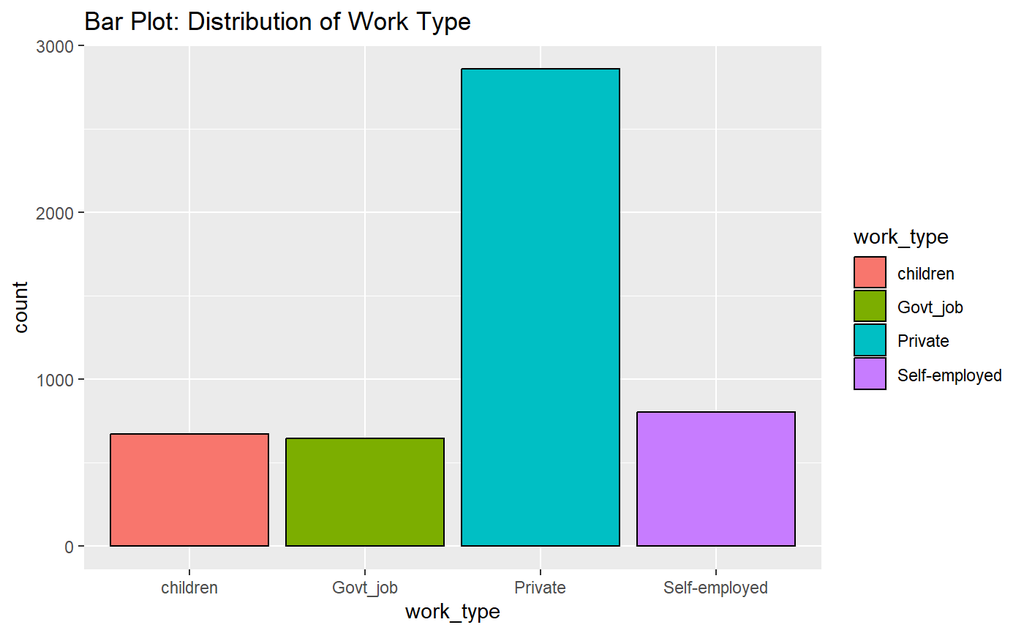

#We notice from this bar plot that the majority of people in this dataset work for a private organization.

#After encoding, ‘Children’ will be number 1, ‘Govt_job’ will be number 2, ‘Private’ will be number 3, and ‘Self-employed’ is number 4.

# 2 - The resulting plot visually shows the distribution of heart disease cases and their association with brain stroke.

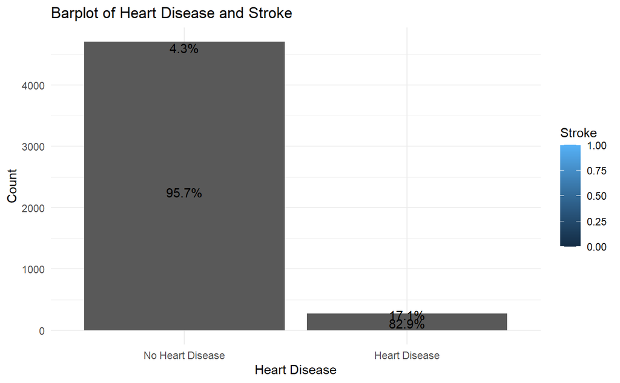

```r
library(ggplot2)
library(dplyr)
  percentages <- brain_stroke %>%
  group_by(heart_disease, stroke) %>%
  summarize(count = n()) %>%
  mutate(percentage = (count / sum(count)) * 100)
ggplot(brain_stroke, aes(x = factor(heart_disease), fill = stroke)) +
  geom_bar() +
  geom_text(data = percentages, aes(label = paste0(round(percentage, 1), "%"), y = count),
            position = position_stack(vjust = 0.5)) +
  labs(x = "Heart Disease", y = "Count", fill = "Stroke") +
  scale_x_discrete(labels = c("No Heart Disease", "Heart Disease")) +
  ggtitle("Barplot of Heart Disease and Stroke") +
  theme_minimal()
```

#The perecentage at the top of the column shows the percentage of having a brain stroke #We notice from this bar plot that people with heart disease have a higher risk of experiencing a brain stroke

# 3 - The resulting plot visually shows the distribution of hypertension cases and their association with brain stroke.

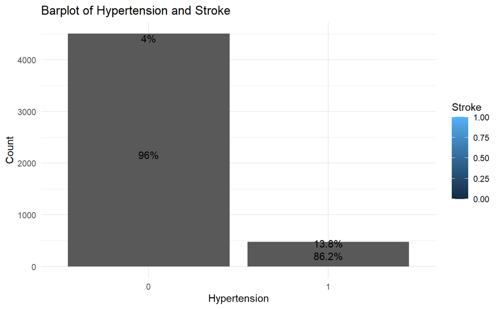

```r
 percentages <- brain_stroke %>%
  group_by(hypertension, stroke) %>%
  summarize(count = n()) %>%
  mutate(percentage = (count / sum(count)) * 100)
ggplot(brain_stroke, aes(x = factor(hypertension), fill = stroke)) +
  geom_bar() +
  geom_text(data = percentages, aes(label = paste0(round(percentage, 1), "%"), y = count),
            position = position_stack(vjust = 0.5)) +
  labs(x = "Hypertension", y = "Count", fill = "Stroke") +
  ggtitle("Barplot of Hypertension and Stroke") +
  theme_minimal()
```

#The perecentage at the top of the column shows the percentage of having a brain stroke #We notice from this bar plot that people with hypertension have a higher risk of experiencing a brain stroke.

# 4 - bar blot that helps visualize if there is any association between smoking status and the likelihood of experiencing a stroke.

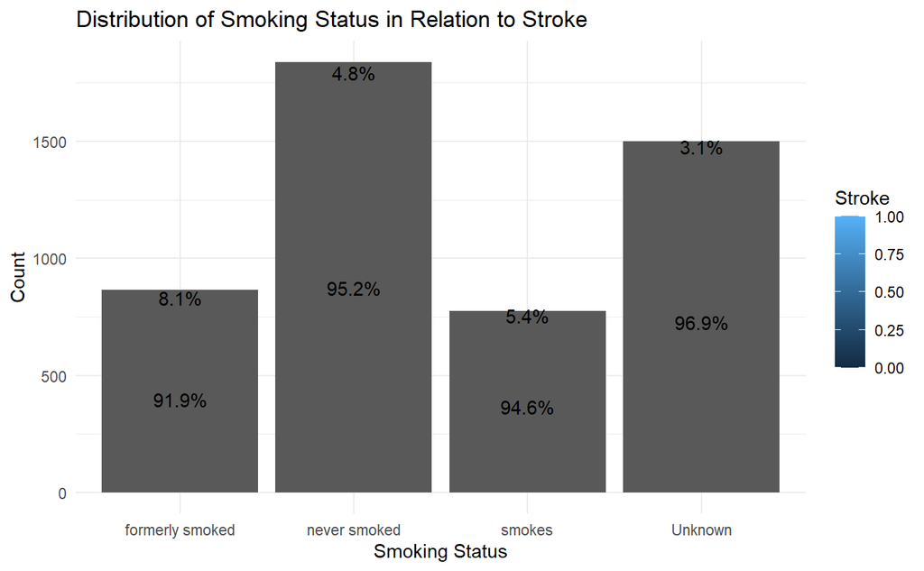

```r
percentages <- brain_stroke %>%
  group_by(smoking_status, stroke) %>%
  summarize(count = n()) %>%
  mutate(percentage = (count / sum(count)) * 100)
ggplot(brain_stroke, aes(x = smoking_status, fill = stroke)) +
  geom_bar() +
  geom_text(data = percentages, aes(label = paste0(round(percentage, 1), "%"), y = count),
            position = position_stack(vjust = 0.5)) +
  labs(x = "Smoking Status", y = "Count", fill = "Stroke") +
  ggtitle("Distribution of Smoking Status in Relation to Stroke") +
  theme_minimal()
```

#The perecentage at the top of the column shows the percentage of having a brain stroke  
#We notice from this bar plot that people who formerly smoked and smokes have a higher risk of experiencing a brain stroke.

#outliers

```r
Outavg_glucose_level = outlier(brain_stroke$avg_glucose_level, logical =TRUE)
sum(Outavg_glucose_level)
```

```
[1] 2
```

```r
Find_outlier = which(Outavg_glucose_level ==TRUE, arr.ind = TRUE)
Outavg_glucose_level
```

[output not shown]

[output cut: 63 more lines]

```r
Find_outlier
```

```
[1] 1488 3058
```

```r
Outbmi = outlier(brain_stroke$bmi, logical =TRUE)
sum(Outbmi)
```

```
[1] 3
```

```r
Find_outlier = which(Outbmi ==TRUE, arr.ind = TRUE)
Outbmi
```

[output not shown]

[output cut: 63 more lines]

```r
Find_outlier
```

```
[1]   18 1834 2136
```

```r
Outage = outlier(brain_stroke$age, logical =TRUE)
sum(Outage)
```

```
[1] 2
```

```r
Find_outlier = which(Outage ==TRUE, arr.ind = TRUE)
Outage
```

[output not shown]

[output cut: 63 more lines]

```r
Find_outlier
```

```
[1] 1488 3058
```

#normlization

| gender | age | hypertension | heart_disease | ever_married | work_type | Residence_type | avg_glucose_level | bmi | smoking_status | stroke |
| --- | --- | --- | --- | --- | --- | --- | --- | --- | --- | --- |
| Male | 0.816894531 | 0 | 1 | Yes | Private | Urban | 0.816894531 | 0.64756447 | formerly smoked | 1 |
| Male | 0.975585938 | 0 | 1 | Yes | Private | Rural | 0.975585938 | 0.53008596 | never smoked | 1 |
| Female | 0.597167969 | 0 | 0 | Yes | Private | Urban | 0.597167969 | 0.58452722 | smokes | 1 |
| Female | 0.963378906 | 1 | 0 | Yes | Self-employed | Rural | 0.963378906 | 0.28653295 | never smoked | 1 |
| Male | 0.987792969 | 0 | 0 | Yes | Private | Urban | 0.987792969 | 0.42979943 | formerly smoked | 1 |
| Male | 0.902343750 | 1 | 1 | Yes | Private | Rural | 0.902343750 | 0.38395415 | never smoked | 1 |
| Female | 0.841308594 | 0 | 0 | No | Private | Urban | 0.841308594 | 0.25214900 | never smoked | 1 |
| Female | 0.951171875 | 0 | 0 | Yes | Private | Urban | 0.951171875 | 0.29226361 | Unknown | 1 |
| Female | 0.987792969 | 1 | 0 | Yes | Private | Rural | 0.987792969 | 0.44985673 | never smoked | 1 |
| Female | 0.743652344 | 0 | 1 | Yes | Govt_job | Rural | 0.743652344 | 0.65329513 | smokes | 1 |

[output cut: 990 more lines]

#discretization #we do not need feature discretization because the data is already well-preprocessed.

#feature selection - correlation analysis (numric)

```r
cor(brain_stroke$age, brain_stroke$stroke)
```

```
[1] 0.2464779
```

```r
cor(brain_stroke$bmi, brain_stroke$stroke)
```

```
[1] 0.05692566
```

```r
cor(brain_stroke$hypertension, brain_stroke$stroke)
```

```
[1] 0.1319652
```

```r
cor(brain_stroke$heart_disease, brain_stroke$stroke)
```

```
[1] 0.1346103
```

```r
cor(brain_stroke$avg_glucose_level, brain_stroke$stroke)
```

```
[1] 0.2464779
```

#There’s a weak correlations between numerical attributes (typically below 0.3) . This implies that feature selection isn’t necessary.

#feature selection - chi square (cateorigal)

```r
chi_squared_result <- chisq.test(table(brain_stroke$gender, brain_stroke$stroke))
print(chi_squared_result)
```

```
    Pearson's Chi-squared test with Yates' continuity correction

data:  table(brain_stroke$gender, brain_stroke$stroke)
X-squared = 0.31352, df = 1, p-value = 0.5755
```

```r
chi_squared_result <- chisq.test(table(brain_stroke$work_type, brain_stroke$stroke))
print(chi_squared_result)
```

```
    Pearson's Chi-squared test

data:  table(brain_stroke$work_type, brain_stroke$stroke)
X-squared = 47.832, df = 3, p-value = 2.312e-10
```

```r
chi_squared_result <- chisq.test(table(brain_stroke$Residence_type, brain_stroke$stroke))
print(chi_squared_result)
```

```
    Pearson's Chi-squared test with Yates' continuity correction

data:  table(brain_stroke$Residence_type, brain_stroke$stroke)
X-squared = 1.2077, df = 1, p-value = 0.2718
```

```r
chi_squared_result <- chisq.test(table(brain_stroke$smoking_status, brain_stroke$stroke))
print(chi_squared_result)
```

```
    Pearson's Chi-squared test

data:  table(brain_stroke$smoking_status, brain_stroke$stroke)
X-squared = 28.734, df = 3, p-value = 2.548e-06
```

```r
chi_squared_result <- chisq.test(table(brain_stroke$ever_married, brain_stroke$stroke))
print(chi_squared_result)
```

```
    Pearson's Chi-squared test with Yates' continuity correction

data:  table(brain_stroke$ever_married, brain_stroke$stroke)
X-squared = 57.481, df = 1, p-value = 3.412e-14
```